# Boosting

Старков Артём

7 ноября 2017 г.

# Library: gbm

```r
library(gbm)
set.seed(555);
```

В подавляющем большинстве библиотек используется реализация градиентного бустинга на регрессионных деревьях, с возможностью изменения аппроксимации функции потерь.

## Построение модели

Функция: gbm(…). Параметры:

- formula – формула;
- distribution [“bernoulli”] – для AdaBoost используется “adaboost”; может использоваться большое количество вариаций для различных задач и функций потерь;
- data – данные;
- n.trees [100] – кол-во итераций (T);
- interaction.depth [1] – количество узлов регрессионного дерева;
- n.minobsinnode [10] – минимальное количество индивидов для создания листа (pre-pruning);
- shrinkage [0.001] – скорость обучения ($\alpha$): дополнительный параметр для оптимизационной задачи градиентного бустинга
  $$b_t := \arg\min_{b \in B} \sum_{i=1}^n(b(x_i)+\alpha\mathcal{L}'(f_i))^2.$$
- bag.fraction [0.5] – для обучения может использоваться не все количество индивидов, а только его часть (стохастический градиентный бустинг); доля индивидов для обучения на следующем шаге;

Для поиска оптимальной глубины дерева может использоваться кросс-валидация; строится k-fold CV для определения глубины дерева, результатом будет k+1-я модель с оптимальным числом уровней. Параметры:

- train.fraction [1.0] – доля индивидов из входных данных (data) для обучения;
- cv.folds [0] – количество моделей для кросс-валидации (k).

## Оптимизация количества итераций N

Функция: gbm.perf(…). Параметры:

- object – модель, полученная из функции gbm;
- method – один из трех методов: “test”, “OOB”, “cv”:
1. “test” – использует параметр train.fraction; делит входные данные на обучающую и тестовую выборки; результат – минимум ошибки на тестовой выборке;
2. “OOB” – использует параметр out-of-bagging; дает консервативную оценку n;
3. “cv” – использует параметр cv.folds; оценка n строится на основе k-fold cv.

## AdaBoost

Построим модель AdaBoost по модельным данным с количеством деревьев $N=1000$. Данные:

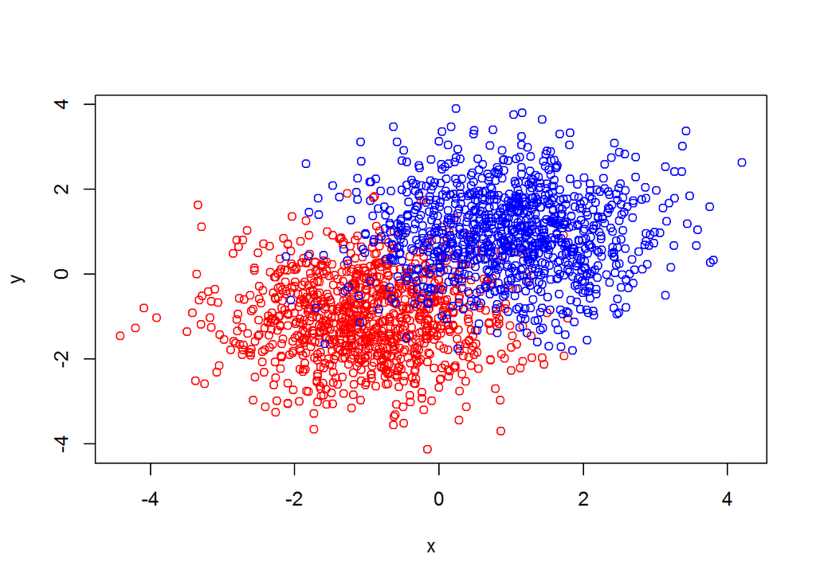

```r
n <- 2000;

d <- data.frame(x=rnorm(n, 1), y=rnorm(n, 1), z=0)
t <- sample(1:n, n/2, FALSE)
d$x[t] <- -d$x[t]
d$y[t] <- -d$y[t]
d$z[t] <- 1

plot(d[d$z==1,]$x, d[d$z==1,]$y, col='red', xlim=c(min(d$x), max(d$x)),
     ylim=c(min(d$y), max(d$y)), xlab='x', ylab='y')
points(d[d$z==0,]$x, d[d$z==0,]$y, col='blue')
```

```r
d.learn <- d[1:(n*0.75),]
d.test  <- d[(n*0.75+1):n,]
```

Оценка оптимального числа итераций T по всем трем способам:

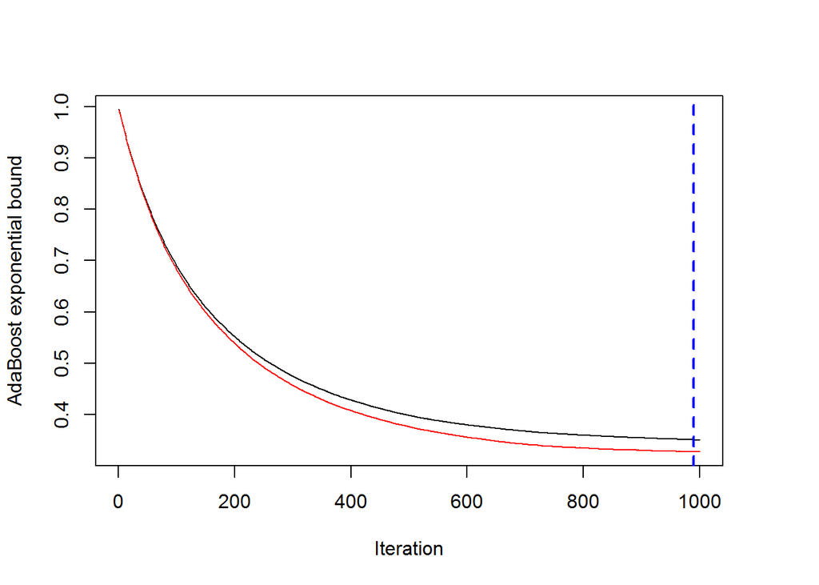

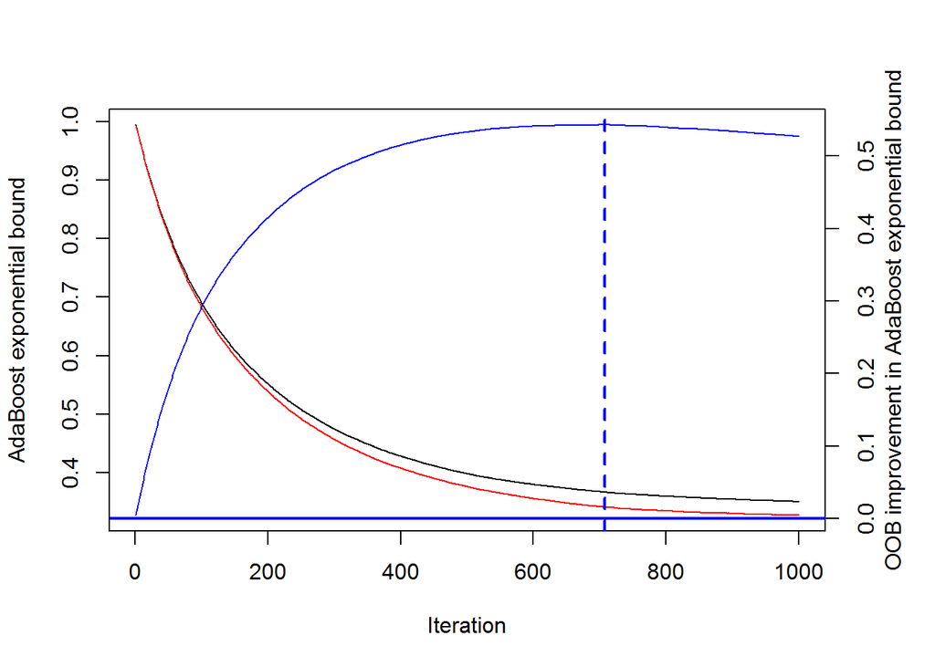

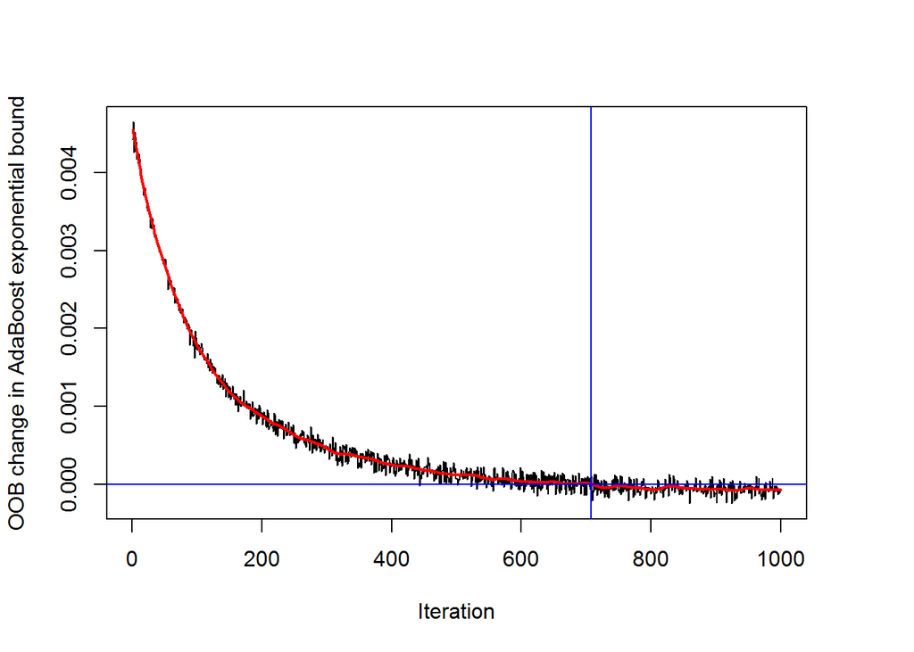

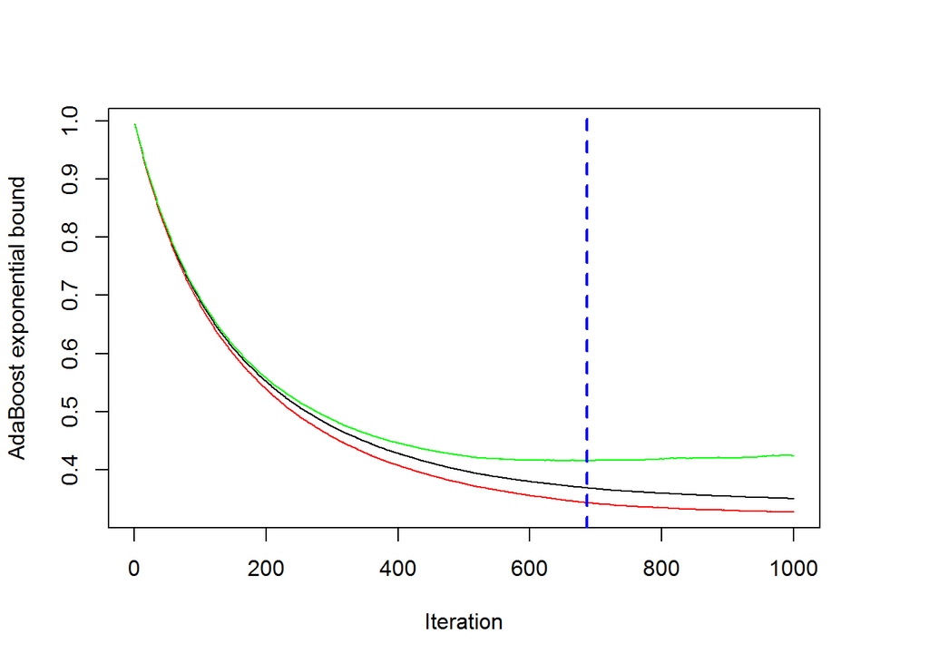

```r
gbmFit <- gbm(
  formula           = z~.,
  distribution      = "adaboost",
  data              = d.learn,
  n.trees           = 1000,
  shrinkage         = 0.01,
  train.fraction    = 0.75,
  cv.folds          = 3
);

N.est <- data.frame(
  test=gbm.perf(gbmFit, method = 'test'),
  OOB = gbm.perf(gbmFit, method = 'OOB', oobag.curve = TRUE),
  CV = gbm.perf(gbmFit, method = 'cv')
)
```

```r
N.est
```

```
##   test OOB  CV
## 1  990 708 687
```

Наибольшая эффективность и вычислительная сложность у кросс-валидации, Out Of Bagging позволяет получить приблизительную оценку для небольших N.

Протестируем полученную модель на разных N.

```r
test_predict <- function(title, model, N) {
  pr = predict(model, d.test, n.trees = N, type='response')
  cat('\n', title, '\nPredict for N =', N, ': mean =',mean(round(pr)==d.test$z))
  print(table(round(pr), d.test$z))
}

test_predict('Test', gbmFit, N.est$test)
```

```
##
##  Test
## Predict for N = 990 : mean = 0.922
##       0   1
##   0 250  10
##   1  29 211
```

```r
test_predict('OOB', gbmFit, N.est$OOB)
```

```
##
##  OOB
## Predict for N = 708 : mean = 0.922
##       0   1
##   0 251  11
##   1  28 210
```

```r
test_predict('CV', gbmFit, N.est$CV)
```

```
##
##  CV
## Predict for N = 687 : mean = 0.924
##       0   1
##   0 252  11
##   1  27 210
```

## Градиентный бустинг с различными функциями потерь

Построим модель gbm для разных функций потерь:

- gaussian: squared error;
- laplace: absolute loss;
- tdist: t-distribution loss;
- bernoulli: logistic regression for 0-1 outcome.

```r
types = c('gaussian', 'laplace', 'tdist', 'bernoulli')
for(type in types) {
  gbmodel <- gbm(
    formula           = z~.,
    distribution      = type,
    data              = d.learn,
    n.trees           = 6000,
    shrinkage         = 0.01,
    train.fraction    = 0.75
  )
  nb <- gbm.perf(gbmodel, method = 'OOB', plot.it = FALSE)
  pr <- predict(gbmodel, d.test, n.trees = nb, type='response')
  cat('\nLoss: ', type, '\nN =', nb, 'p =',mean(round(pr)==d.test$z))
  table(pr, d.test$z)
}
```

```
##
## Loss:  gaussian
## N = 484 p = 0.904
## Loss:  laplace
## N = 5998 p = 0.846
## Loss:  tdist
## N = 575 p = 0.904
## Loss:  bernoulli
## N = 816 p = 0.924
```

## Regression

Простейший вариант регрессии. Для расчета ошибки как среднеквадратичного отклонения используется distribution = “gaussian”.

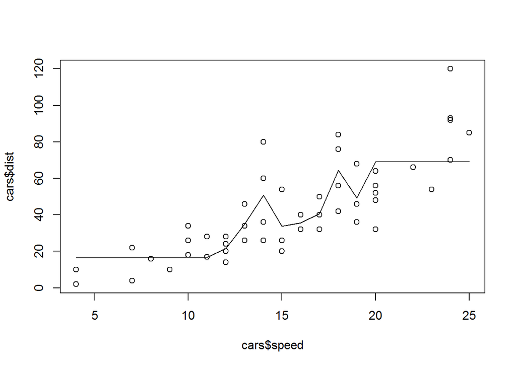

```r
data(cars)

regr <- gbm(dist~speed,
  data              = cars,
  shrinkage         = 0.01,
  distribution      = "gaussian",
  interaction.depth = 3,
  bag.fraction      = 0.7,
  n.trees           = 50000
)
p <- predict(regr, n.trees = 50000)
plot(cars$speed, cars$dist)
lines(cars$speed, p)
```

```r
cat('Sq. error:', mean((p-cars$dist)^2))
```

```
## Sq. error: 241.2823
```

## Сравнение с Random Forest

Сравним AdaBoost, как показавший лучшие результаты среди использовавшихся на приведенных данных, с Random forest

```r
library(randomForest)
rf <- randomForest(z~., d.learn)
res <- round(predict(rf, d.test))
table(res, d.test$z)
```

```
##
## res   0   1
##   0 252  17
##   1  27 204
```

```r
mean(res == d.test$z)
```

```
## [1] 0.912
```

```r
gbmFit <- gbm(
  formula           = z~.,
  distribution      = "adaboost",
  data              = d.learn,
  n.trees           = 20000
)
res = round(predict(gbmFit, d.test, n.trees = 20000, type='response'))
table(res, d.test$z)
```

```
##
## res   0   1
##   0 253  11
##   1  26 210
```

```r
mean(res == d.test$z)
```

```
## [1] 0.926
```

### Смещенные данные с выбросами

```r
d0 <- data.frame(x=rnorm(n, 1), y=rnorm(n, 1), z=0)

# выбросы
tout <- sample(1:n, 50, FALSE)
d0[tout, ]$x <- d0[tout, ]$x*20
d0[tout, ]$y <- d0[tout, ]$y*20

tz <- sample(1:n, n/2, FALSE)
d0[tz,]$x <- -d0[tz,]$x
d0[tz,]$y <- -d0[tz,]$y
d0[tz,]$z <- 1

t0 <- sample(1:n, n/4, FALSE)
d0.learn <- d0[setdiff(1:n, t0),]
d0.test  <- d0[t0,]

# rforest
rf <- randomForest(z~., d0.learn)
res <- round(predict(rf, d0.test))
table(res, d0.test$z)
```

```
##
## res   0   1
##   0 226  28
##   1  22 224
```

```r
cat('Predict:', mean(res == d0.test$z))
```

```
## Predict: 0.9
```

```r
# gbm
gbmFit <- gbm(
  formula           = z~.,
  distribution      = "adaboost",
  data              = d0.learn,
  n.trees           = 10000,
  train.fraction    = 0.75
);
N <- gbm.perf(gbmFit, FALSE, method = 'OOB')
res <- round(predict(gbmFit, d0.test, n.trees = N, type='response'))
table(res, d0.test$z)
```

```
##
## res   0   1
##   0 220  21
##   1  28 231
```

```r
cat('Predict:', mean(res == d0.test$z))
```

```
## Predict: 0.902
```

```r
# для сравнения SVM
library(e1071)
msvm = svm(z~., d0.learn)
res <- round(predict(msvm, d0.test))
table(res, d0.test$z)
```

```
##
## res   0   1
##   0 223  24
##   1  25 228
```

```r
cat('Predict:', mean(res == d0.test$z))
```

```
## Predict: 0.902
```

### Сложноразделимые данные

```r
d0 <- data.frame(x=rnorm(n, 1, 3), y=rnorm(n, 1, 3), z=0)

tz <- sample(1:n, n/2, FALSE)
d0[tz,]$x = -d0[tz,]$x
d0[tz,]$y = -d0[tz,]$y
d0[tz,]$z = 1

t0 <- sample(1:n, n/4, FALSE)
d0.learn <- d0[setdiff(1:n, t0),]
d0.test  <- d0[t0,]

# rforest
rf <- randomForest(z~., d0.learn)
res <- round(predict(rf, d0.test))
table(res, d0.test$z)
```

```
##
## res   0   1
##   0 170  95
##   1  86 149
```

```r
cat('Predict:', mean(res == d0.test$z))
```

```
## Predict: 0.638
```

```r
# gbm
gbmFit <- gbm(
  formula           = z~.,
  distribution      = "adaboost",
  data              = d0.learn,
  n.trees           = 10000,
  train.fraction    = 0.75
);
N <- gbm.perf(gbmFit, FALSE, method = 'OOB')
res <- round(predict(gbmFit, d0.test, n.trees = N, type='response'))
table(res, d0.test$z)
```

```
##
## res   0   1
##   0 173  87
##   1  83 157
```

```r
cat('Predict:', mean(res == d0.test$z))
```

```
## Predict: 0.66
```

```r
# SVM
msvm = svm(z~., d0.learn)
res <- round(predict(msvm, d0.test))
table(res, d0.test$z)
```

```
##
## res   0   1
##   0 168  84
##   1  88 160
```

```r
cat('Predict:', mean(res == d0.test$z))
```

```
## Predict: 0.656
```